# Pandas Tutorial

pandas is a column-oriented data analysis API. It's a great tool for analyzing input data that is used by many machine learning frameworks.  
In this quick workshop I will teach you the basic functions of pandas in order to be able to better manipulate your data

## Importing pandas

- Whenever we want to import pandas we usually write it at the top of our code as seen below
- we give it the alias pd for convention and anytime we wish to call it we refer to it as pd

```python
import pandas as pd
pd.__version__
```

```
'1.0.5'
```

## Structure

Pandas utilizes two main data structures

- **Series:** A series is a single column
- **DataFrame:** A dataframe is a datable made up of one or more series

Let's start by creating a series object:

```python
cities = pd.Series(['San Diego', 'Los Angeles', 'Sacramento', 'San Francisco']) #Create a new series
cities #print series
```

```
0        San Diego
1      Los Angeles
2       Sacramento
3    San Francisco
dtype: object
```

The DataFrame object is can be created by passing a dictionary that maps string column names to their respective series.  
If the series don't match in length, NA/NaN values will fil in the missing spots. Lets create a dataframe:

```python
population = pd.Series([234234, 100232, 50000]) #create a new series

df = pd.DataFrame({'City': cities, 'City Population':population}) #create dataframe from series
df #print dataframe
```

|  | City | City Population |
| --- | --- | --- |
| 0 | San Diego | 234234.0 |
| 1 | Los Angeles | 100232.0 |
| 2 | Sacramento | 50000.0 |
| 3 | San Francisco | NaN |

## Reading Files

- most of the time we will read in files to our dataframes not create them
- pandas read a plethora of files but for our purposes we will be reading a csv file
- by convention we like to store the file in a variable called df
- df stands for dataframe

we will be using the same csv(comma seperated values) file as in the next part of the workshop

```python
df = pd.read_csv('data-collection/glassdoor_job.csv')
```

```python
df #prints the dataframe
```

|  | Job Title | Salary Estimate | Job Description | Rating | Company Name | Location | Headquarters | Size | Founded | Type of ownership | Industry | Sector | Revenue | Competitors |
| --- | --- | --- | --- | --- | --- | --- | --- | --- | --- | --- | --- | --- | --- | --- |
| 0 | Software Engineer | $107K-$157K (Glassdoor est.) | MedBill is looking for a Software Engineer to ... | 4.4 | MedBill\r\n4.4 | Boone, NC | Pittsburgh, PA | 51 to 200 employees | 2005 | Company - Private | Staffing & Outsourcing | Business Services | $5 to $10 million (USD) | -1 |
| 1 | Software Engineer | $107K-$157K (Glassdoor est.) | Job Description:\r\nInfogroup is looking for t... | 3.6 | Yes Marketing\r\n3.6 | Marshfield, WI | Chicago, IL | 201 to 500 employees | 2000 | Subsidiary or Business Segment | Advertising & Marketing | Business Services | Unknown / Non-Applicable | -1 |
| 2 | Full Stack Software Engineer | $107K-$157K (Glassdoor est.) | Why OJO?\r\nWe’re on a mission to empower peop... | 4.7 | OJO Labs\r\n4.7 | Austin, TX | Austin, TX | 201 to 500 employees | 2015 | Company - Private | Internet | Information Technology | $10 to $25 million (USD) | -1 |
| 3 | Full Stack Software Engineer | $107K-$157K (Glassdoor est.) | Corporate Traffic Logistics is a 28-year-old a... | 4.2 | Corporate Traffic Logistics\r\n4.2 | Jacksonville, FL | Jacksonville, FL | 51 to 200 employees | 1992 | Company - Private | Logistics & Supply Chain | Transportation & Logistics | Unknown / Non-Applicable | -1 |
| 4 | Software Engineer | $107K-$157K (Glassdoor est.) | Ungerboeck Software is looking to hire the bes... | 4.0 | Ungerboeck Software International\r\n4.0 | O'Fallon, MO | O'Fallon, MO | 201 to 500 employees | 1985 | Company - Private | Computer Hardware & Software | Information Technology | $25 to $50 million (USD) | -1 |
| ... | ... | ... | ... | ... | ... | ... | ... | ... | ... | ... | ... | ... | ... | ... |
| 995 | Engineer - Software (Mid-Senior) - Job ID | $67K-$92K (Glassdoor est.) | Is it time for a new opportunity? Want to work... | 4.6 | Space Dynamics Laboratory\r\n4.6 | Albuquerque, NM | Logan, UT | 501 to 1000 employees | 1959 | Nonprofit Organization | Aerospace & Defense | Aerospace & Defense | $50 to $100 million (USD) | -1 |
| 996 | Mechanical Systems Engineer, OCONUS, Afghanistan | $67K-$92K (Glassdoor est.) | Mechanical Systems Engineer, OCONUS, Afghanist... | 2.3 | MD Helicopters\r\n2.3 | Mesa, AZ | Mesa, AZ | 501 to 1000 employees | 2006 | Company - Private | Aerospace & Defense | Aerospace & Defense | $50 to $100 million (USD) | -1 |
| 997 | Senior Software Engineer | $67K-$92K (Glassdoor est.) | Introduction\r\n\r\n\r\nASML is one of the wor... | 3.6 | ASML\r\n3.6 | San Diego, CA | Veldhoven, Netherlands | 10000+ employees | 1984 | Company - Public | Computer Hardware & Software | Information Technology | $5 to $10 billion (USD) | Applied Materials, KLA, Lam Research |
| 998 | Senior Software Engineer | $67K-$92K (Glassdoor est.) | Introduction\r\n\r\n\r\nASML is one of the wor... | 3.6 | ASML\r\n3.6 | San Diego, CA | -1 | -1 | -1 | -1 | -1 | -1 | -1 | -1 |
| 999 | Sr. Systems Engineer, Quality Systems | $67K-$92K (Glassdoor est.) | The Role:\r\n\r\nReporting to the Senior Manag... | 3.6 | Moderna Therapeutics\r\n3.6 | Norwood, MA | Cambridge, MA | 501 to 1000 employees | 2011 | Company - Public | Biotech & Pharmaceuticals | Biotech & Pharmaceuticals | $1 to $5 million (USD) | -1 |

1000 rows × 14 columns

## Understanding the data

- There are a couple ways we can look at the data in the dataframe to get more info

Below I will explain the different functions

```python
df.info() #get info on the type of the data
```

```
<class 'pandas.core.frame.DataFrame'>
RangeIndex: 1000 entries, 0 to 999
Data columns (total 14 columns):
 #   Column             Non-Null Count  Dtype
---  ------             --------------  -----
 0   Job Title          1000 non-null   object
 1   Salary Estimate    1000 non-null   object
 2   Job Description    1000 non-null   object
 3   Rating             1000 non-null   float64
 4   Company Name       1000 non-null   object
 5   Location           1000 non-null   object
 6   Headquarters       1000 non-null   object
 7   Size               1000 non-null   object
 8   Founded            1000 non-null   int64
 9   Type of ownership  1000 non-null   object
 10  Industry           1000 non-null   object
 11  Sector             1000 non-null   object
 12  Revenue            1000 non-null   object
 13  Competitors        1000 non-null   object
dtypes: float64(1), int64(1), object(12)
memory usage: 109.5+ KB
```

```python
df.columns #shows all columns in the dataframe
```

```
Index(['Job Title', 'Salary Estimate', 'Job Description', 'Rating',
       'Company Name', 'Location', 'Headquarters', 'Size', 'Founded',
       'Type of ownership', 'Industry', 'Sector', 'Revenue', 'Competitors'],
      dtype='object')
```

```python
df.head() #shows first 5 rows
```

|  | Job Title | Salary Estimate | Job Description | Rating | Company Name | Location | Headquarters | Size | Founded | Type of ownership | Industry | Sector | Revenue | Competitors |
| --- | --- | --- | --- | --- | --- | --- | --- | --- | --- | --- | --- | --- | --- | --- |
| 0 | Software Engineer | $107K-$157K (Glassdoor est.) | MedBill is looking for a Software Engineer to ... | 4.4 | MedBill\r\n4.4 | Boone, NC | Pittsburgh, PA | 51 to 200 employees | 2005 | Company - Private | Staffing & Outsourcing | Business Services | $5 to $10 million (USD) | -1 |
| 1 | Software Engineer | $107K-$157K (Glassdoor est.) | Job Description:\r\nInfogroup is looking for t... | 3.6 | Yes Marketing\r\n3.6 | Marshfield, WI | Chicago, IL | 201 to 500 employees | 2000 | Subsidiary or Business Segment | Advertising & Marketing | Business Services | Unknown / Non-Applicable | -1 |
| 2 | Full Stack Software Engineer | $107K-$157K (Glassdoor est.) | Why OJO?\r\nWe’re on a mission to empower peop... | 4.7 | OJO Labs\r\n4.7 | Austin, TX | Austin, TX | 201 to 500 employees | 2015 | Company - Private | Internet | Information Technology | $10 to $25 million (USD) | -1 |
| 3 | Full Stack Software Engineer | $107K-$157K (Glassdoor est.) | Corporate Traffic Logistics is a 28-year-old a... | 4.2 | Corporate Traffic Logistics\r\n4.2 | Jacksonville, FL | Jacksonville, FL | 51 to 200 employees | 1992 | Company - Private | Logistics & Supply Chain | Transportation & Logistics | Unknown / Non-Applicable | -1 |
| 4 | Software Engineer | $107K-$157K (Glassdoor est.) | Ungerboeck Software is looking to hire the bes... | 4.0 | Ungerboeck Software International\r\n4.0 | O'Fallon, MO | O'Fallon, MO | 201 to 500 employees | 1985 | Company - Private | Computer Hardware & Software | Information Technology | $25 to $50 million (USD) | -1 |

```python
df.tail() #shows last 5 rows
```

|  | Job Title | Salary Estimate | Job Description | Rating | Company Name | Location | Headquarters | Size | Founded | Type of ownership | Industry | Sector | Revenue | Competitors |
| --- | --- | --- | --- | --- | --- | --- | --- | --- | --- | --- | --- | --- | --- | --- |
| 995 | Engineer - Software (Mid-Senior) - Job ID | $67K-$92K (Glassdoor est.) | Is it time for a new opportunity? Want to work... | 4.6 | Space Dynamics Laboratory\r\n4.6 | Albuquerque, NM | Logan, UT | 501 to 1000 employees | 1959 | Nonprofit Organization | Aerospace & Defense | Aerospace & Defense | $50 to $100 million (USD) | -1 |
| 996 | Mechanical Systems Engineer, OCONUS, Afghanistan | $67K-$92K (Glassdoor est.) | Mechanical Systems Engineer, OCONUS, Afghanist... | 2.3 | MD Helicopters\r\n2.3 | Mesa, AZ | Mesa, AZ | 501 to 1000 employees | 2006 | Company - Private | Aerospace & Defense | Aerospace & Defense | $50 to $100 million (USD) | -1 |
| 997 | Senior Software Engineer | $67K-$92K (Glassdoor est.) | Introduction\r\n\r\n\r\nASML is one of the wor... | 3.6 | ASML\r\n3.6 | San Diego, CA | Veldhoven, Netherlands | 10000+ employees | 1984 | Company - Public | Computer Hardware & Software | Information Technology | $5 to $10 billion (USD) | Applied Materials, KLA, Lam Research |
| 998 | Senior Software Engineer | $67K-$92K (Glassdoor est.) | Introduction\r\n\r\n\r\nASML is one of the wor... | 3.6 | ASML\r\n3.6 | San Diego, CA | -1 | -1 | -1 | -1 | -1 | -1 | -1 | -1 |
| 999 | Sr. Systems Engineer, Quality Systems | $67K-$92K (Glassdoor est.) | The Role:\r\n\r\nReporting to the Senior Manag... | 3.6 | Moderna Therapeutics\r\n3.6 | Norwood, MA | Cambridge, MA | 501 to 1000 employees | 2011 | Company - Public | Biotech & Pharmaceuticals | Biotech & Pharmaceuticals | $1 to $5 million (USD) | -1 |

[output not shown]

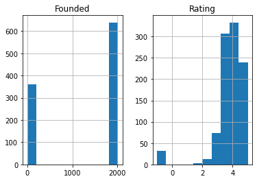

```python
df.hist() #Create quick histogram on numeric columns
```

## Column Manipulation

- There are different ways to access and modify different columns
- Pandas offers a myriad of ways to manipulate its data but I will show you the most common

### Let's start off by accessing a single column

```python
df['Headquarters'] #Here we supply dataframe with the name of the column to access that single column
```

```
0              Pittsburgh, PA
1                 Chicago, IL
2                  Austin, TX
3            Jacksonville, FL
4                O'Fallon, MO
                ...
995                 Logan, UT
996                  Mesa, AZ
997    Veldhoven, Netherlands
998                        -1
999             Cambridge, MA
Name: Headquarters, Length: 1000, dtype: object
```

### Above we used bracket notation

- Bracket notation is typically used if your column name has Spaces or funky characters like periods
- Below we use dot notation which performs the same task but instead we use a dot

```python
df.Headquarters
```

```
0              Pittsburgh, PA
1                 Chicago, IL
2                  Austin, TX
3            Jacksonville, FL
4                O'Fallon, MO
                ...
995                 Logan, UT
996                  Mesa, AZ
997    Veldhoven, Netherlands
998                        -1
999             Cambridge, MA
Name: Headquarters, Length: 1000, dtype: object
```

### Now lets manipulate rows

- in pandas we can use loc functions in order to specify a single rows , a type of row, or all rows
- This concept is usually a little tough to wrap your head around but with practice it becomes much easier

```python
df.loc[0:7 , 'Headquarters'] #[Specify rows , Specify Columns]
```

```
0      Pittsburgh, PA
1         Chicago, IL
2          Austin, TX
3    Jacksonville, FL
4        O'Fallon, MO
5     Kansas City, MO
6        Monterey, CA
7      Pittsburgh, PA
Name: Headquarters, dtype: object
```

### Pandas has many more functions to it but I've learned that the best way to learn pandas is to practice it

- These are the bare necessities we need in order to get started and really learn pandas
- Lets move on the the data-cleaning.py in order to apply our pandas skills

credits to: [Google's intro to pandas](https://colab.research.google.com/notebooks/mlcc/intro_to_pandas.ipynb#scrollTo=nqndFVXVlbPN)